# GEOG-533 Lab 9

Marisol Muniz

## Question 1

Use R package **UScensus2010county** to complete the following tasks: (20 pt.)

### Question 1(a)

Plot a map of New York counties using the **plot** function.

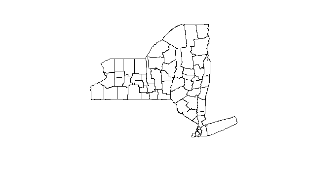

```r
if (!require(UScensus2010)) {install.packages("UScensus2010")}
library(UScensus2010)
if (!require(UScensus2010county)) {install.county("osx")}
if (!require(UScensus2010tract)) {install.tract("osx")}
library(UScensus2010county)
library(UScensus2010tract)
data(new_york.county10)
shp.1a <- new_york.county10
plot(shp.1a)
```

### Question 1(b)

Plot a map of New York counties using the **qtm** function.

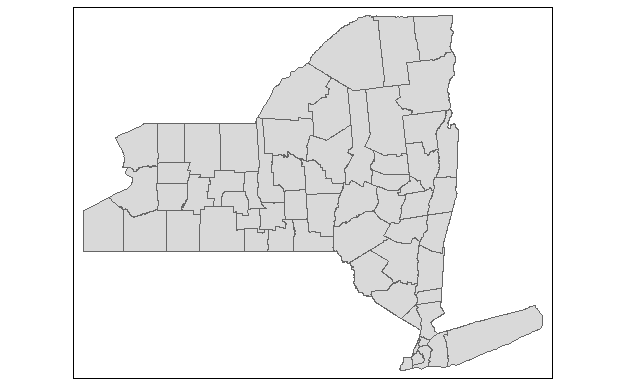

```r
if (!require(tmap)) {install.packages("tmap")}
library(tmap)
qtm(shp.1a)
```

### Question 1(c)

How many counties in New York State?

```r
nrow(new_york.county10)
```

```
[1] 62
```

### Question 1(d)

Whatâs the 3-digit **fips** code of Broome County?

```r
df.1 <- shp.1a@data
broome.fips <- df.1[df.1$NAME10 == "Broome",]$county
print(broome.fips)
```

```
[1] "007"
```

### Question 1(e)

Compute descriptive statistics of the population column (**P0010001**), including total, minimum, maximum, mean, median, and skewness.

```r
if (!require(fBasics)) install.packages("fBasics")
library(fBasics)
pop <- df.1$P0010001
basicStats(pop)
```

|  | pop |
| --- | --- |
| nobs | 6.200000e+01 |
| NAs | 0.000000e+00 |
| Minimum | 4.836000e+03 |
| Maximum | 2.504700e+06 |
| 1. Quartile | 5.124350e+04 |
| 3. Quartile | 2.310603e+05 |
| Mean | 3.125500e+05 |
| Median | 9.130100e+04 |
| Sum | 1.937810e+07 |
| SE Mean | 6.760931e+04 |

[output cut: 6 more lines]

### Question 1(f)

Create a histogram and a boxplot of the population.

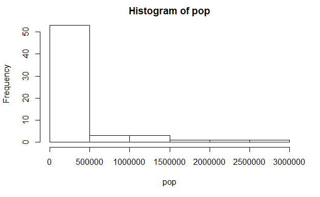

```r
hist(pop)
```

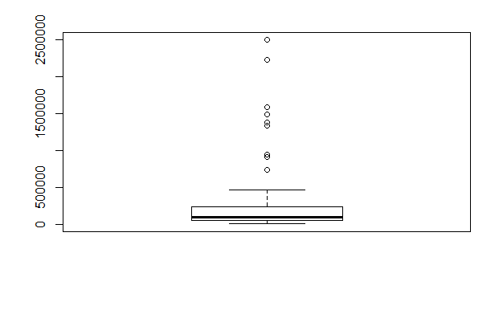

```r
boxplot(pop)
```

## Question 2

Use R package **UScensus2010tract** to complete the following tasks: (20 pt.)

```r
if (!require(UScensus2010)) {install.packages("UScensus2010")}
library(UScensus2010)
if (!require(UScensus2010county)) {install.county("osx")}
if (!require(UScensus2010tract)) {install.tract("osx")}
library(UScensus2010county)
library(UScensus2010tract)
data(new_york.tract10)
shp.2 <- new_york.tract10
df.2 <- shp.2@data
```

### Question 2(a)

Plot a map of New York census tracts using the **plot** function.

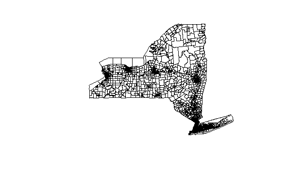

```r
plot(shp.2)
```

### Question 2(b)

Compute the total population based on census tracts.

```r
sum(df.2$P0010001)
```

```
[1] 19378102
```

### Question 2(c)

Select all census tracts in Broome County and plot the map.

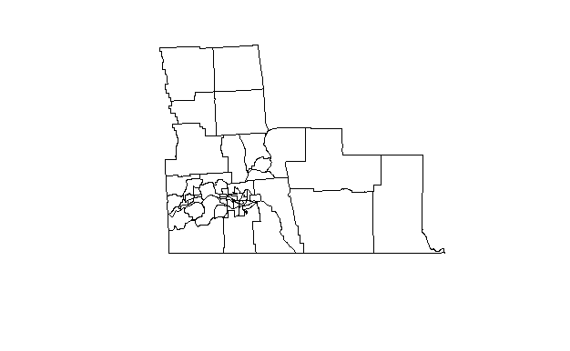

```r
broome <- shp.2[shp.2$county == "007",]
plot(broome)
```

```r
NA
```

### Question 2(d)

Whatâs the total population of Broome County?

```r
sum(broome$P0010001)
```

```
[1] 200600
```

### Question 2(e)

Create a histogram and a boxplot of population based on census tracts of Broome County.

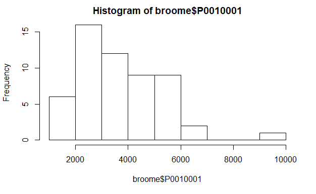

```r
hist(broome$P0010001)
```

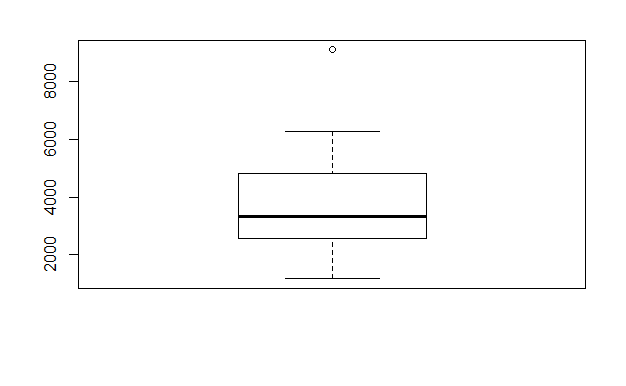

```r
boxplot(broome$P0010001)
```

### Question 2(f)

Select the first five columns of the shapefile of Broome County census tract; add a new population ratio column (= census tract population / county population); save the new shapefile to the hard drive.

```r
broome2 <- broome[1:5]
broome2@data["PopRatio"] <- broome2$P0010001/200600
library(rgdal)
writeOGR(broome2, dsn = "output", layer = "broome2", driver = "ESRI Shapefile", overwrite_layer = TRUE)
```

```
NAs introduced by coercion
```

## Question 3

Use R packages **raster** and **ncdf4** to complete the following tasks: (20 pt.)

```r
if (!require(ncdf4)) {install.packages("ncdf4")}
library(ncdf4)
library(raster)
```

### Question 3(a)

Load the multi-band raster dataset âNDVI.ncâ into R.

```r
ndvi <- raster("NDVI.nc")
ndvi
```

```
class       : RasterLayer
band        : 1  (of  36  bands)
dimensions  : 360, 720, 259200  (nrow, ncol, ncell)
resolution  : 0.5, 0.5  (x, y)
extent      : -180, 180, -90, 90  (xmin, xmax, ymin, ymax)
coord. ref. : +proj=longlat +datum=WGS84 +ellps=WGS84 +towgs84=0,0,0
data source : H:/GEOG533/Labs/Lab9/NDVI.nc
names       : Normalized.Difference.Vegetation.Index
z-value     : 2000-01-01
zvar        : NDVI
```

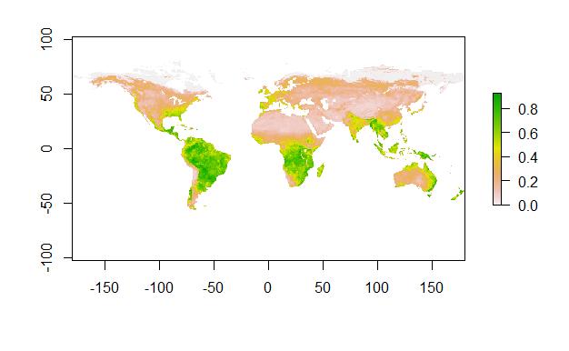

```r
plot(ndvi)
```

### Question 3(b)

Get the basic information about the dataset, including the number of rows, columns, cells, and bands; spatial resolution, extent, bounding box, and projection.

```r
nrow(ndvi)
```

```
[1] 360
```

```r
ncol(ndvi)
```

```
[1] 720
```

```r
ncell(ndvi)
```

```
[1] 259200
```

```r
nbands(ndvi)
```

```
[1] 36
```

```r
res(ndvi)
```

```
[1] 0.5 0.5
```

```r
extent(ndvi)
```

```
class       : Extent
xmin        : -180
xmax        : 180
ymin        : -90
ymax        : 90
```

```r
bbox(ndvi)
```

```
    min max
s1 -180 180
s2  -90  90
```

```r
projection(ndvi)
```

```
[1] "+proj=longlat +datum=WGS84 +ellps=WGS84 +towgs84=0,0,0"
```

### Question 3(c)

Aggregate all bands to generate a mean NDVI raster and a maximum NDVI raster; save the two new raster datasets to the hard drive.

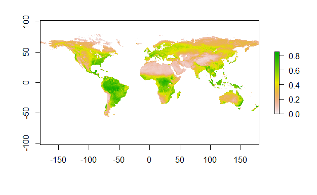

```r
ndvi.rb <- brick("NDVI.nc")
ndvi.mean <- calc(ndvi.rb, fun = mean)
plot(ndvi.mean)
```

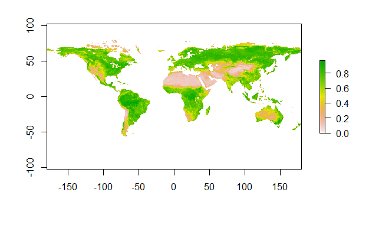

```r
writeRaster(ndvi.mean, filename = "mean_ndvi", overwrite = TRUE)
ndvi.max <- calc(ndvi.rb, fun = max)
plot(ndvi.max)
```

```r
writeRaster(ndvi.mean, filename = "max_ndvi", overwrite = TRUE)
```

### Question 3(d)

Plot the maps of monthly NDVI of the year 2001

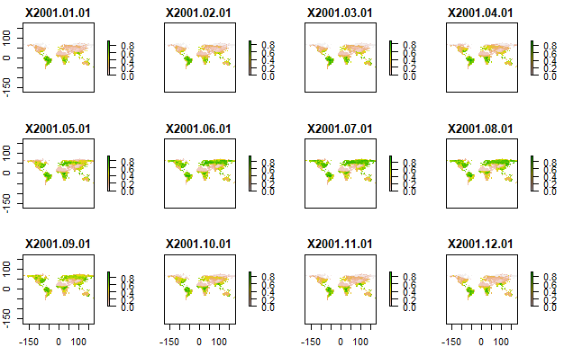

### Question 3(e)

Create histograms of monthly NDVI of the year 2001.

```
size changed to n because it cannot be larger than n when replace is FALSE39% of the raster cells were used (of which 42% were NA). 58093 values used.
```

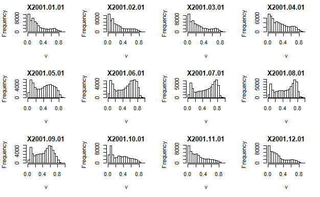

```r
hist(ndvi2000)
```

### Question 3(f)

Plot the NDVI map of July 2000; click any location with data on the map and retrieve the NDVI time series for all years; plot the NDVI time series of the selected location.

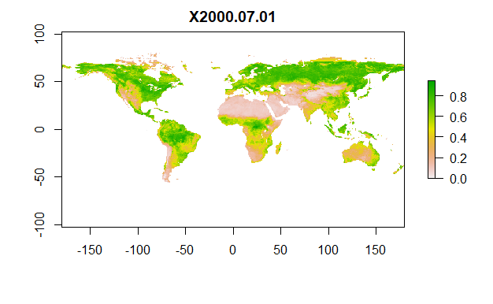

```r
plot(ndvi.rb,7)
```

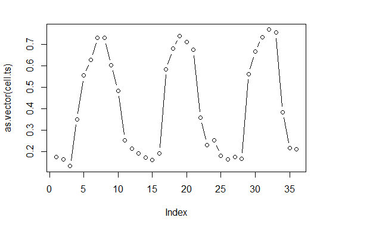

```r
cell <- cellFromXY(ndvi.rb, cbind(-75, 50))
cell.ts <- ndvi.rb[cell]
plot(as.vector(cell.ts), type="b")
```